# Interactive ggplot2 graphics with ggiraph

Joshua French

2022-05-03

# What are interactive graphics?

Interactive graphics are visual displays that dynamically provide information to users based on the user interacting with the graphic.

There are a few types of interactive graphics related to R.

- Graphics that you interact within R itself (e.g., **plotly** (Sievert et al. 2021))
- Graphics that are produced within an html document that can be viewed within a web browser (e.g., **ggiraph** (Gohel and Skintzos 2022) and **htmlwidgets** (Vaidyanathan et al. 2021))
- Graphics that can be manipulated within a web browser or server (**shiny**, Chang et al. (2021))

# Interactive **ggplot2** graphics with **ggiraph**

**ggiraph** is a powerful package (Gohel and Skintzos 2022) that allows you to create interactive **ggplot2** (Wickham 2016; Wickham et al. 2021) graphics. The **ggiraph** package is technically an `htmlwidget`, though you don’t need to know about the **htmlwidgets** package to use it. **ggiraph** can be utilized within **shiny** applications, but we don’t describe that here.

The **ggiraph** package:

- Extends **gpplot2** by adding interactive geometries, scales, guides, and themes.
- Provides the aesthetics `tooltip`, `data_id`, and `onclick` to add interactivity to a graphic.

More specifically, the **ggiraph** package extends the various **ggplot2** components with interactive versions such as:

- Interactive geom functions: e.g., `geom_bar_interactive`, `geom_boxplot_interactive`, `geom_histogram_interactive`, etc.
- Interactive scale functions: e.g., `scale_color_continuous_interactive`, `scale_fill_gradient_interactive`, `scale_size_discrete_interactive`, etc.
- Interactive guide functions: e.g., `guide_bins_interactive`, `guide_colorbar_interactive`, `guide_legend_interactive`, etc.
- Interactive theme elements: `element_line_interactive`, `element_rect_interactive`, `element_text_interactive`.

The functions above generally provide three aesthetics to let you add interactivity to a standard **ggplot** graphic:

- `data_id`: a variable that contains the id to associate with each graphical element. This will usually result in the element changing color when the user’s mouse hovers over the element.
- `tooltip`: a variable that contains text to be displayed when the mouse hovers over the graphical element.
- `onclick`: a variable that contains a javascript command to be executed when an element is clicked.

**Once the interactive ggplot object has been specified and assigned a name, the `girafe` function is used to display the interactive graphic in the web browser.**

A great many useful interactive graphics can be created using the interactive geometries alone. We will focus on this aspect of interactive **ggplot2** graphics below. We list some of the interactive geometries provided by **ggiraph** in Table 1 below.

Table 1: Common interactive geometries provided by **ggiraph**.

[output not shown]

# The `diamonds` data set

To illustrate creation of interactive graphics using **ggiraph**, we will use the `diamonds` data set from the **ggplot2** package (Wickham et al. 2021). The `diamonds` data set is a data frame (technically, a tibble data frame) with 53940 rows and 10 variables. The `diamonds` documentation (`?ggplot2::diamonds`) describes the variables as:

- `price`: the diamond’s price in US dollars
- `carat`: the diamond’s weight
- `cut`: the quality of the diamond’s cut (`Fair`, `Good`, `Very Good`, `Premium`, `Ideal`)
- `color`: the diamond’s color from (`D` = best to `J` = worst).
- `clarity`: the diamond’s clarity (I1 = worst, SI2, SI1, VS2, VS1, VVS2, VVS1, IF = best)
- `x`: the diamond’s length (mm)
- `y`: the diamond’s width (mm)
- `z`: the diamond’s depth (mm)
- `depth`: the diamond’s total depth percentage = 100 * 2 * `z` / (`x` + `y`) (the depth divided by the average of the length and width).
- `table`: the diamond’s relative width of the top width to widest point.

We start by loading the data set into memory.

```r
data(diamonds, package = "ggplot2")
```

# Basic useage of the `data_id` and `tooltip` aesthetics

```r
library(ggplot2)  # for graphical output
library(ggiraph)  # to make ggplot2 interactive
library(dplyr)  # for basic data frame manipulation
```

In the code below we create an interactive bar chart of the `cut` variable in the `diamonds` data set. We will examine how the different interactive aesthetics impact the graphic.

**The `data_id` aesthetic changes the color of a graphical element when the user hovers over that element.** In the code below, we map the `cut` variable with `data_id` so that the bar for each cut type changes color when we hover our mouse over the bar. By itself, the `data_id` aesthetic isn’t very useful.

```r
ibar_data_id <- ggplot(data = diamonds) + geom_bar_interactive(aes(x = cut, data_id = cut))
# the girafe actually displays the graphic
girafe(ggobj = ibar_data_id)
```

[interactive chart not shown]

**The `tooltip` aesthetic allows text to be displayed when the mouse cursor hovers over a graphical element**. In the code chunk below, we associate the `cut` variable with the `tooltip` aesthetic. The `cut` associated with each bar will be displayed when the user’s mouse cursor hovers over that bar. Since we haven’t specified hte `data_id`, the bars do not change color.

```r
ibar_tooltip <- ggplot(data = diamonds) + geom_bar_interactive(aes(x = cut, tooltip = cut))
girafe(ggobj = ibar_tooltip)
```

[interactive chart not shown]

If we specify both the `data_id` and `tooltip` aesthetics in our graphic, then the `bar` will “light up” when the user’s mouse cursor hovers over the bar and the associated `tooltip` text will be displayed. We specify both aesthetics in the code chunk below.

```r
ibar_both <- ggplot(data = diamonds) + geom_bar_interactive(aes(x = cut, tooltip = cut,
    data_id = cut))
girafe(ggobj = ibar_both)
```

[interactive chart not shown]

# Using `after_stat` for advanced interactive graphics

We sometimes want to add information to our interactive graphic that is likely computed during the graphic’s construction but is not immediately accessible. For example, it would be helpful to add the count associated with each bar of a bar chart as a tooltip. The count of each factor level must be computed to create bars of the appropriate height but that information is not accessible by default. How do we get access to that information?

The `after_stat` function can be used to access information computed during a graphic’s construction. One of the challenges with using the `after_stat` function is that you may not know what variables are computed for the graphic. In order to access that information, we can use the `layer_data` function on our constructed object. Consider the output produced when applying the `layer_data` function to `ibar_both`.

```r
# peek at information used to produce the bar chart
layer_data(ibar_both)
```

```
##       y count prop x flipped_aes   tooltip   data_id PANEL group ymin  ymax
## 1  1610  1610    1 1       FALSE      Fair      Fair     1     1    0  1610
## 2  4906  4906    1 2       FALSE      Good      Good     1     2    0  4906
## 3 12082 12082    1 3       FALSE Very Good Very Good     1     3    0 12082
## 4 13791 13791    1 4       FALSE   Premium   Premium     1     4    0 13791
## 5 21551 21551    1 5       FALSE     Ideal     Ideal     1     5    0 21551
##   xmin xmax colour   fill size linetype alpha
## 1 0.55 1.45     NA grey35  0.5        1    NA
## 2 1.55 2.45     NA grey35  0.5        1    NA
## 3 2.55 3.45     NA grey35  0.5        1    NA
## 4 3.55 4.45     NA grey35  0.5        1    NA
## 5 4.55 5.45     NA grey35  0.5        1    NA
```

We see that the `count` variable was computed when producing that bar chart. The `count` variable indicates the number of values each level of `cut` appears in the data set (1610 for `Fair`, 4906 for `Good`, etc.) To display the `count` associated with each bar as a `tooltip`, we wrap the `after_stat` function around the `count` variable. Our interactive bar chart now more useful, as the count assicated with each bar is displayed when our mouse cursor hovers over a bar.

```r
ibar_count <- ggplot(data = diamonds) + geom_bar_interactive(aes(x = cut, tooltip = after_stat(count),
    data_id = after_stat(count)))
girafe(ggobj = ibar_count)
```

[interactive chart not shown]

# Using the `onclick` aesthetic

**The `onclick` aesthetic enables dynamic JavaScript actions to run when the user clicks on certain graphical elements.** This is the most difficult interactive aesthetic to work with. The only examples I have seen are opening a web browser to a certain website when the graphical element is clicked. In order to do this, we need to learn a bit more about how to include quotes within a character string.

## How to make quotes within a string

Recall that to create a character string in R, you place single quotes (' ') or double quotes (" ") around some text. E.g., we create character string vector with the words `ham` and `spam` in the code chunk below.

```r
c("ham", "spam")
```

```
## [1] "ham"  "spam"
```

In order to perform `onclick` actions, we need to actually include quotes inside a character string. In order to properly include quotes in a character string in R you must alternate use of the characters `"` and `'` to indicate the beginning and end of the quote. If you want to include a single or double quote in a character string, then you need to surround: a single quote by double quotes or a double quote by single quotes. If you want to include multiple single or double quotes in a string you have to be more creative and use something like the `paste` or `paste0` functions to combine complex strings into a single string.

The Merriam-Webster dictionary (Merriam-Webster.com Dictionary, n.d.) defines onomatopoeia as

> The naming of a thing or action by a vocal imitation of the sound associated with it (such as buzz, hiss).

In the code chunk below, we demonstrate how to include single or double quotes within the character strings for several examples of onomatopeoia. Note that when printing a character string with a double quote that R will put a backslash `\` before the double quote to indicate that it is part of the string.

First, we create the character string `buzz`.

```r
# character string buzz
"buzz"
```

```
## [1] "buzz"
```

```r
# character string buzz surrounded by double quotes
" \"buzz\" "
```

```
## [1] " \"buzz\" "
```

Now, we create the character string `buzz` surrounded by single quotes. We place double quotes outside the single quotes to get the desired effect.

```r
# character string buzz surrounded by single quotes
" 'buzz' "
```

```
## [1] " 'buzz' "
```

We now create a lengthier character string that places single quotes around multiple words in the character string.

```r
# a lengthier character string created using double quotes that uses single
# quotes within the string
"Some examples of onomatopoeia are 'buzz', 'hiss', and 'boom'"
```

```
## [1] "Some examples of onomatopoeia are 'buzz', 'hiss', and 'boom'"
```

Lastly, to create a character string that includes both double and single quotes, we need to use the `paste0` function to combine separate character strings into a longer character string having the desired behavior.

```r
# create the string: She said, 'Some examples of onomatopoeia are 'buzz',
# 'hiss', and 'boom''.
paste0("She said, ", "\"Some examples of onomatopoeia are ", "'buzz', 'hiss', and 'boom'",
    "\".")
```

```
## [1] "She said, \"Some examples of onomatopoeia are 'buzz', 'hiss', and 'boom'\"."
```

We will use what we have learned in this section to create click functionality in an interactive graphic.

### Adding click functionality to an interactive graphic

To open a website based on a user clicking a graphical element (e.g., a bar or observation), you must specify what website to open for each observation. A column of your data frame must supply a character string for each observation of the form `window.open("... website to open ...")`. This can be quite complex.

In the example below, we choose to open a google search when the user clicks one of the bars of our bar chart. A google search will take the form `"https://www.google.com/search?q=thing"`, where `thing` is a sequence of words linked by the plus sign. e.g., to search for “Which president was the best athlete,” we would need `"https://www.google.com/search?q=which+president+was+the+best+athlete"`. To then turn this into a click action, we need to add the `window.open()` command around the website, specifically: `window.open(https://www.google.com/search?q=which+president+was+the+best+athlete")`

For the bar graph, we want to open a google search for the type of diamond cut (Good, Premium, Ideal, etc.) when the user clicks their mouse on the associated bar. We first add a variable, `bar_google`, to the `diamonds` data frame that contains the google query with the cut of diamond.

```r
# add variable that would perform a google search for each observation's cut
diamonds <- diamonds |>
    mutate(bar_google = paste0("https://www.google.com/search?q=diamond+cut+", as.character(cut)))
# look at first 3 values in bar_google
diamonds |>
    select(bar_google) |>
    print(n = 3)
```

```
## # A tibble: 53,940 x 1
##   bar_google
##   <chr>
## 1 https://www.google.com/search?q=diamond+cut+Ideal
## 2 https://www.google.com/search?q=diamond+cut+Premium
## 3 https://www.google.com/search?q=diamond+cut+Good
## # ... with 53,937 more rows
```

Next, we add another variable, `bar_onclick` to the `diamonds` data frame to add the `window.open(" ... ")` part of the `onlick` command to the `bar_google` variable. We use the `paste0` function and a series of single and double quotes to get the desired format.

```r
# add column that actually performs the google search on click
diamonds <- diamonds |>
    mutate(bar_onclick = paste0("window.open(\"", bar_google, "\")"))
# look at first 3 values in bar_onclick
diamonds |>
    select(bar_onclick) |>
    print(n = 3)
```

```
## # A tibble: 53,940 x 1
##   bar_onclick
##   <chr>
## 1 "window.open(\"https://www.google.com/search?q=diamond+cut+Ideal\")"
## 2 "window.open(\"https://www.google.com/search?q=diamond+cut+Premium\")"
## 3 "window.open(\"https://www.google.com/search?q=diamond+cut+Good\")"
## # ... with 53,937 more rows
```

Lastly, we map the `bar_onclick` variable to the `onclick` aesthetic in our interactive bar chart so that when the user clicks a bar, a corresponding google search for that diamond cut is opened.

```r
# specify interactive bar chart that searches for the cut if associated bar
# clicked
ibar_click <- ggplot(data = diamonds) + geom_bar_interactive(aes(x = cut, data_id = cut,
    tooltip = cut, onclick = bar_onclick))
girafe(ggobj = ibar_click)
```

[interactive chart not shown]

# The `starwars` data set

To illustrate the creation of additional interactive graphics using **ggiraph**, we will use the `starwars` data set from the **dplyr** package (Wickham et al. 2022). As stated in its documentation (`?dplyr::starwars`) the original data were obtained from the Star Wars API ([https://swapi.dev/])(https://swapi.dev/) and were updated based on additional research into gender and sex determinations of the characters.

The `starwars` data set is a data frame (technically, a tibble data frame) with 87 rows and 14 variables:

- `name`: the character’s name.
- `height`: the character’s height (cm).
- `mass`: the character’s mass (kg).
- `hair_color`: the character’s hair color.
- `skin_color`: the character’s skin color.
- `eye_color`: the character’s eye color.
- `birth_year`: the character’s birth year (BBY = Before Battle of Yavin).
- `sex`: the character’s biological sex (male, female, hermaphroditic, or none (as in the case for Droids)).
- `gender`: the character’s gender role or gender identity as determined by their personality or the way they were programmed (as in the case for Droids).
- `homeworld`: the name of the character’s homeworld.
- `species`: the character’s species.
- `films`: the films the character appeared in.
- `vehicles`: the vehicles the character has piloted.
- `starships`: the starships the character has piloted.

We start by loading the data set into memory.

```r
data(starwars, package = "dplyr")
```

# Creating an interactive scatter plot

In this section, we create some interactive scatter plots using the `starwars` data. We will create a scatter plot of each observation’s `mass` (kg) versus height (`cm`).

A simple (non-interactive) scatter plot is shown below.

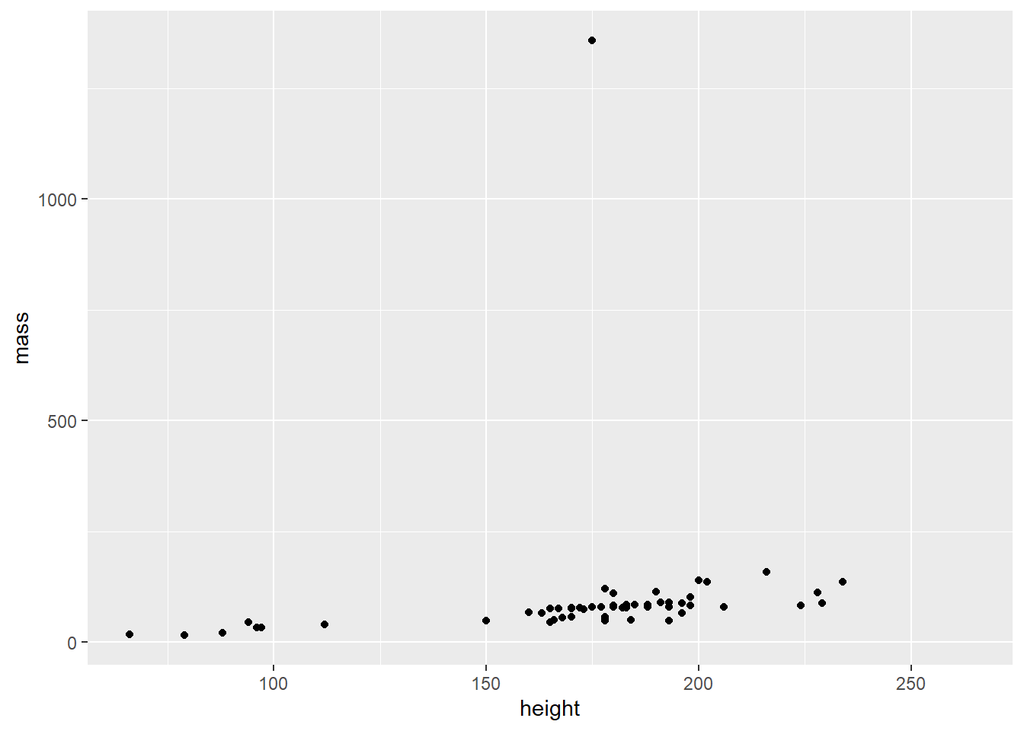

```r
ggplot(data = starwars) + geom_point(aes(x = height, y = mass))
```

For the most part, there is a linear trend among the observations, However, there is a clear outlier around (175, 1375). An interactive plot would help us to identify this observation.

## A simple interactive scatterplot

In the interactive scatter plot below, we use `geom_point_interative` to construct the interactive scatter plot and use the `name` variable as a `tooltip` and `data_id` so that the character’s name appears when we hover over an observation. What character is the outlier?

```r
iscatter <- ggplot(data = starwars) + geom_point_interactive(aes(x = height, y = mass,
    tooltip = name, data_id = name))
girafe(ggobj = iscatter)
```

[interactive chart not shown]

## Creating a more complex tooltip

While the previous graphic was useful for identifying the character name of the outlying observation, it might be interesting to create a `tooltip` that provides additional information such as the character’s home world and eye color. To do this, we add a new variable to the `starwars` data frame, `complex_tooltip`, that combines the variables `name`, `homeworld`, and `eye_color` into a single character vector with some additional explanatory text. The `\n` indicates a new line so that the three characteristics are on separate lines in the `tooltip`.

```r
starwars <- starwars |>
    mutate(complex_tooltip = paste0("name = ", name, "\n home world = ", homeworld,
        "\n eye color = ", eye_color))
starwars |>
    select(complex_tooltip) |>
    print(n = 3)
```

```
## # A tibble: 87 x 1
##   complex_tooltip
##   <chr>
## 1 "name = Luke Skywalker\n home world = Tatooine\n eye color = blue"
## 2 "name = C-3PO\n home world = Tatooine\n eye color = yellow"
## 3 "name = R2-D2\n home world = Naboo\n eye color = red"
## # ... with 84 more rows
```

We now add the `complex_tooltip` variable as the `tooltip` in an updated scatter plot to create a more informative interactive scatter plot.

```r
iscatter2 <- ggplot(data = starwars) + geom_point_interactive(aes(x = height, y = mass,
    tooltip = complex_tooltip, data_id = name))
girafe(ggobj = iscatter2)
```

[interactive chart not shown]

## Creating a clickable scatterplot

While Star Wars is a popular movie franchise, not all of us are experts. It might be helpful to make each observation clickable so that a google search for the character’s name opens when the observation is clicked.

Similar to our previous `onclick` aesthetic example, we use the `paste0` function to create a variable, `google_search`, that is a string for the google search query of each character’s name.

```r
# create google link
starwars <- starwars |>
    mutate(google_search = paste0("https://www.google.com/search?q=", as.character(name)))
# print top 3 results
starwars |>
    select(google_search) |>
    print(n = 3)
```

```
## # A tibble: 87 x 1
##   google_search
##   <chr>
## 1 https://www.google.com/search?q=Luke Skywalker
## 2 https://www.google.com/search?q=C-3PO
## 3 https://www.google.com/search?q=R2-D2
## # ... with 84 more rows
```

Next, we use the `paste0` function to add the `window.open("...")` text around the desired search and assign that string the name `complex_onclick`.

```r
starwars <- starwars |>
    mutate(complex_onclick = paste0("window.open(\"", google_search, "\")"))
# print top 3 results
starwars |>
    select(complex_onclick) |>
    print(n = 3)
```

```
## # A tibble: 87 x 1
##   complex_onclick
##   <chr>
## 1 "window.open(\"https://www.google.com/search?q=Luke Skywalker\")"
## 2 "window.open(\"https://www.google.com/search?q=C-3PO\")"
## 3 "window.open(\"https://www.google.com/search?q=R2-D2\")"
## # ... with 84 more rows
```

Lastly, we specify the `onclick` aesthetic in our interactive scatter plot to create an interactive scatterplot that allows the user to perform a google search for a character by clicking on the relevant observation. Click on some of the observations to learn more info about the associated character. Did you know all of the characters?

```r
iscatter3 <- ggplot(data = starwars) + geom_point_interactive(aes(x = height, y = mass,
    data_id = name, tooltip = name, onclick = complex_onclick))
girafe(ggobj = iscatter3)
```

[interactive chart not shown]

## Adding an interactive smooth to a scatterplot

It is very natural to add an (interactive) regression line to a scatter plot. In the context of the `starwars` data set, it makes sense to fit a robust regression line so that the outlier doesn’t adversely affect the fitted model. To add the robust regression line to the scatterplot, we use `method = MASS::rlm` in `geom_smooth_interactive` to use the `rlm` function (robust linear model) from the **MASS** package (Ripley 2022). Similar to the example in the documentation of `geom_smooth_interactive`, we specify `tooltip = "smooth`. The interactive robust regression line is added to the scatter plot and displays the word `smooth` when you hover over the line. This is not particularly useful.

```r
iscatter4 <- ggplot(data = starwars, aes(x = height, y = mass)) + geom_point_interactive(aes(data_id = name,
    tooltip = name)) + geom_smooth_interactive(method = MASS::rlm, se = FALSE, tooltip = "smooth")
girafe(ggobj = iscatter4)
```

[interactive chart not shown]

Our graphic would be more useful if the regression equation were displayed when the user hovered over the regression line.O know of no easy way to do this using `geom_smooth_interactive`. Instead, we first manually fit the robust linear model, extract the coefficients, and then use the coefficients to create a character string for the regression equation (recall that `\n` means to start a new line).

```r
# fit the robust linear model
rlmod <- MASS::rlm(mass ~ height, data = starwars)
# extract the coefficients
coeffs <- rlmod$coefficients
# turn coefficients into a useful character string
equation <- paste0("intercept: ", round(coeffs[[1]], 2), "\nslope: ", round(coeffs[[2]],
    2))
equation
```

```
## [1] "intercept: -25.55\nslope: 0.58"
```

Instead of using `geom_smooth_interactive` to draw our regression line, we use `geom_abline_interactive` to manually add the regression line and use the character string we created as the `tooltip`. The equation of the regression line is now displayed when we hover the mouse cursor over the line.

```r
iscatter5 <- ggplot(data = starwars, aes(x = height, y = mass)) + geom_point_interactive(aes(data_id = name,
    tooltip = name)) + geom_abline_interactive(intercept = coeffs[1], slope = coeffs[2],
    tooltip = equation, data_id = coeffs[1], color = "blue")
girafe(ggobj = iscatter5)
```

[interactive chart not shown]

## References

Chang, Winston, Joe Cheng, JJ Allaire, Carson Sievert, Barret Schloerke, Yihui Xie, Jeff Allen, Jonathan McPherson, Alan Dipert, and Barbara Borges. 2021. *Shiny: Web Application Framework for r*. https://shiny.rstudio.com/.

Gohel, David, and Panagiotis Skintzos. 2022. *Ggiraph: Make Ggplot2 Graphics Interactive*. https://davidgohel.github.io/ggiraph/.

Merriam-Webster.com Dictionary, Merriam-Webster. n.d. “"Onomatopoeia".” https://www.merriam-webster.com/dictionary/onomatopoeia.

Ripley, Brian. 2022. *MASS: Support Functions and Datasets for Venables and Ripley’s MASS*. http://www.stats.ox.ac.uk/pub/MASS4/.

Sievert, Carson, Chris Parmer, Toby Hocking, Scott Chamberlain, Karthik Ram, Marianne Corvellec, and Pedro Despouy. 2021. *Plotly: Create Interactive Web Graphics via Plotly.js*. https://CRAN.R-project.org/package=plotly.

Vaidyanathan, Ramnath, Yihui Xie, JJ Allaire, Joe Cheng, Carson Sievert, and Kenton Russell. 2021. *Htmlwidgets: HTML Widgets for r*. https://github.com/ramnathv/htmlwidgets.

Wickham, Hadley. 2016. *Ggplot2: Elegant Graphics for Data Analysis*. Springer-Verlag New York. https://ggplot2.tidyverse.org.

Wickham, Hadley, Winston Chang, Lionel Henry, Thomas Lin Pedersen, Kohske Takahashi, Claus Wilke, Kara Woo, Hiroaki Yutani, and Dewey Dunnington. 2021. *Ggplot2: Create Elegant Data Visualisations Using the Grammar of Graphics*. https://CRAN.R-project.org/package=ggplot2.

Wickham, Hadley, Romain François, Lionel Henry, and Kirill Müller. 2022. *Dplyr: A Grammar of Data Manipulation*. https://CRAN.R-project.org/package=dplyr.